# Data Science Capstone - Week2 Milestone report

Anand venkataraman

Sunday, May 14,2017

### Introduction

The goal of this milestone report is to display that

we have gotten used to working with the data, and we are on track to create our prediction algorithm. The motivation for this milestone report is to:

demonstrate that we have downloaded the data and have successfully loaded it in. create a basic report of summary statistics about the data sets. report any interesting findings that we amassed so far. get feedback on our plans for creating a prediction algorithm and Shiny app.

### Loading Libraries

#### The following libraries are loaded before any computation is carried out.

```r
knitr::opts_chunk$set(echo = TRUE)
library(tm)
```

```r
library(wordcloud)
library(RWeka)
library(ggplot2)
```

## Loading Data

#### Data for the analysis in this course is provided on this website: https://d396qusza40orc.cloudfront.net/dsscapstone/dataset/Coursera-SwiftKey.zip. These files are zipped, and they are provided in German, Russian, Finnish and English. For this project, we are only using the English files.

#### The Twitter, Blogs, and News data files are loaded as show below.

```r
#Load data
twitter <- readLines(con <- file("C://Users//AnandVasumathi//Documents//Coursera-SwiftKey//final//en_US//en_US.twitter.txt"), encoding = "UTF-8", skipNul = TRUE)
blog <- readLines(con <- file("C://Users//AnandVasumathi//Documents//Coursera-SwiftKey//final//en_US//en_US.blogs.txt"), encoding = "UTF-8", skipNul = TRUE)
news <- readLines(con <- file("C://Users//AnandVasumathi//Documents//Coursera-SwiftKey//final//en_US//en_US.news.txt"), encoding = "UTF-8", skipNul = TRUE)
close(con)
```

```r
knitr::opts_chunk$set(echo = TRUE)
#check the length
twit.length <- length(twitter)
blog.length <- length(blog)
news.length <- length(news)

#check the file size in megabyte
twit.size <- file.info("C://Users//AnandVasumathi//Documents//Coursera-SwiftKey//final//en_US//en_US.twitter.txt")$size /1024 /1000
blog.size <- file.info("C://Users//AnandVasumathi//Documents//Coursera-SwiftKey//final//en_US//en_US.blogs.txt")$size /1024 /1000
news.size <- file.info("C://Users//AnandVasumathi//Documents//Coursera-SwiftKey//final//en_US//en_US.news.txt")$size /1024 /1000

#length of the longest line seen
tMax<-nchar(twitter[which.max(nchar(twitter))])
bMax<-nchar(blog[which.max(nchar(blog))])
nMax<-nchar(news[which.max(nchar(news))])

#word count
tWords <- sum(sapply(gregexpr("\\S+", twitter), length))
bWords <- sum(sapply(gregexpr("\\S+", blog), length))
nWords <- sum(sapply(gregexpr("\\S+", news), length))
```

## Prepare and Clean the Datasets

#### We then conver the file format and remove any “NA” and/or missing values.

```r
knitr::opts_chunk$set(echo = TRUE)
##remove all weird characters by converting UTF-8 to ASCII
twitter<- iconv(twitter, 'UTF-8', 'ASCII', "byte")
blog<- iconv(blog, 'UTF-8', 'ASCII', "byte")
news<- iconv(news, 'UTF-8', 'ASCII', "byte")

##remove all NA and/or missing value
twitter <- (twitter[!is.na(twitter)])
blog <- (blog[!is.na(blog)])
news <- (news[!is.na(news)])
```

## Due to the huge volume of data, we decided to take only 1% sample from the dataset for further analysis. The datasets are then combined and convered to corpus format.

```r
knitr::opts_chunk$set(echo = TRUE)
twitterSample<-sample(twitter, length(twitter)*0.01)
blogSample<-sample(blog, length(blog)*0.01)
newsSample<-sample(news, length(news)*0.01)
sample <- c(twitterSample,blogSample,newsSample)
doc.vec <- VectorSource(sample)
```

## Data in the corpus format is then cleaned with the following methods:

#### 1) by converting texts into plain texts of lower case, without punctuations, numbers, and white spaces. A wordcloud has been illustrated as follows to show the 100 most frequently used words in the sample (from news, blogs and Twitter).

```r
knitr::opts_chunk$set(echo = TRUE)
doc.corpus <- Corpus(doc.vec)
doc.corpus<- tm_map(doc.corpus, tolower)
doc.corpus<- tm_map(doc.corpus, removePunctuation)
doc.corpus<- tm_map(doc.corpus, removeNumbers)
doc.corpus <- tm_map(doc.corpus, stripWhitespace)
```

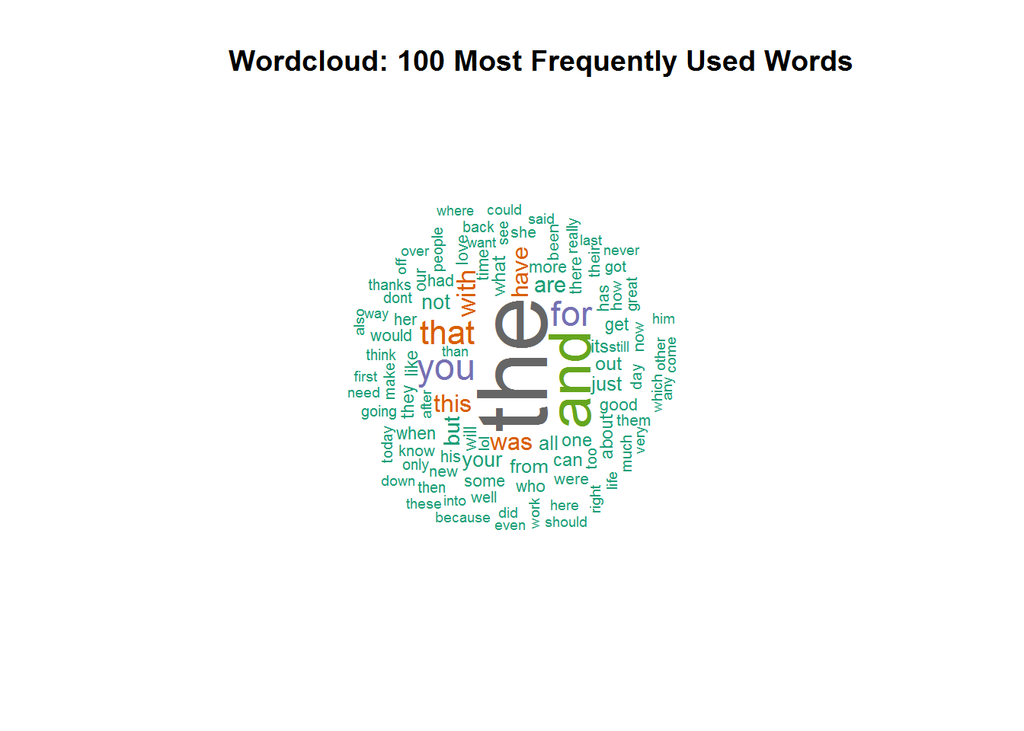

```r
library("SnowballC")
wordcloud(doc.corpus, max.words = 100, random.order = FALSE,rot.per=0.35, use.r.layout=FALSE,colors=brewer.pal(8, "Dark2"))
title("Wordcloud: 100 Most Frequently Used Words")
```

```r
knitr::opts_chunk$set(echo = TRUE)
doc.corpus <- Corpus(doc.vec)
doc.corpus<- tm_map(doc.corpus, tolower)
doc.corpus<- tm_map(doc.corpus, removePunctuation)
doc.corpus<- tm_map(doc.corpus, removeNumbers)
doc.corpus <- tm_map(doc.corpus, stripWhitespace)
doc.corpus <- tm_map(doc.corpus, removeWords, stopwords("english"))
doc.corpus <- tm_map(doc.corpus, stemDocument)
```

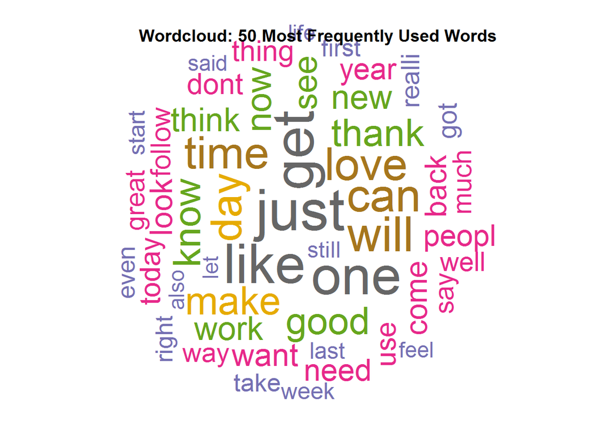

```r
wordcloud(doc.corpus, max.words = 50, random.order = FALSE,rot.per=0.35, use.r.layout=FALSE,colors=brewer.pal(8, "Dark2"))
title("Wordcloud: 50 Most Frequently Used Words")
```

```r
knitr::opts_chunk$set(echo = TRUE)
doc.corpus <- Corpus(doc.vec)
doc.corpus<- tm_map(doc.corpus, tolower)
doc.corpus <- tm_map(doc.corpus, removeWords, stopwords("english"))
doc.corpus <- tm_map(doc.corpus, stemDocument)
doc.corpus<- tm_map(doc.corpus, removePunctuation)
doc.corpus<- tm_map(doc.corpus, removeNumbers)
doc.corpus <- tm_map(doc.corpus, stripWhitespace)
```

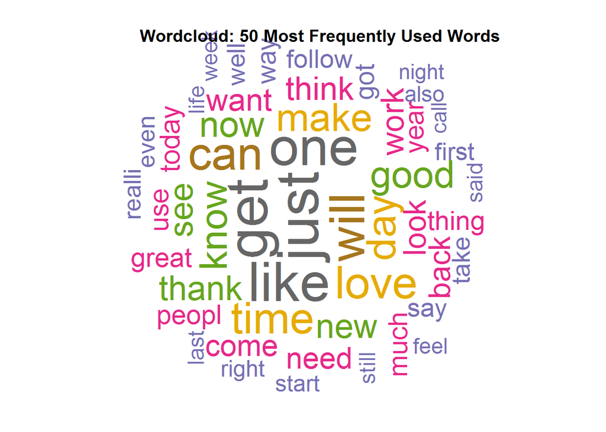

```r
wordcloud(doc.corpus, max.words = 50, random.order = FALSE,rot.per=0.35, use.r.layout=FALSE,colors=brewer.pal(8, "Dark2"))
title("Wordcloud: 50 Most Frequently Used Words")
```

#### Both method 2 and 3 gets similar results. Compared to the 1st method, method 2 and 3 removes all the meaningless words and produces slightly more meaningful singular words.

### Analysing Word Frequency

#### In this section, we will analyse the word frequency in the corpus via N-gram tokenisation. As shown below, we formulated the function to calculate the frequency of words.

```r
nGram <- function(ng, data, lowfreq) {
  # Tokenizer splits a string into an n-gram (a stream of terms or tokens) with min and max grams.
  ngramtokenizer <- function(x) NGramTokenizer(x, Weka_control(min = ng, max = ng))
  # construct a term-document matrix
  ngram_tdm <- TermDocumentMatrix(data, control = list(tokenize = ngramtokenizer))
  # find the frequent terms in a term-doc matrix with a lower frequency bound
  freq <- findFreqTerms(ngram_tdm, lowfreq=lowfreq)
  # tabulating frequency of the frequent terms in the form of data frame
  ngram_freq <- rowSums(as.matrix(ngram_tdm[freq,]))
  ngram_freq <- data.frame(ngramTerm=names(ngram_freq), Frequency=ngram_freq)
  ngram_freq <- ngram_freq[order(-ngram_freq$Frequency),]
  rownames(ngram_freq) <- c(1:nrow(ngram_freq))
  return(ngram_freq)
}
```

### Unigram Analysis

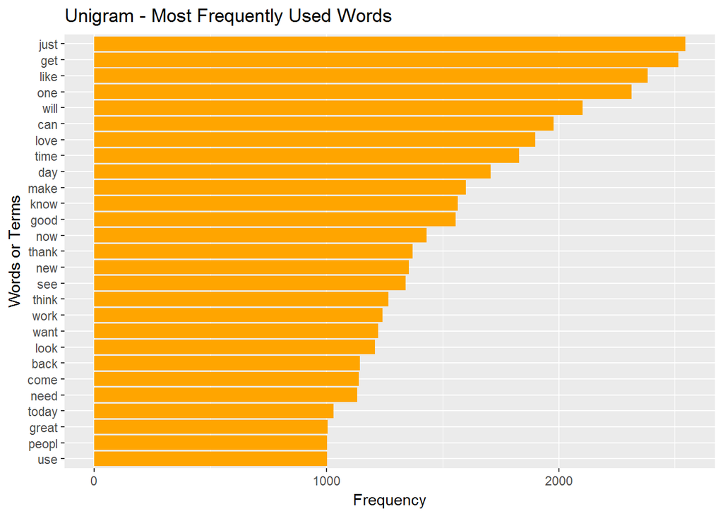

```r
ngram <- nGram(1, doc.corpus, 1000)

ggplot(data=ngram,
       aes(x=reorder(ngramTerm, Frequency), y=Frequency)) +
  geom_bar(stat = "identity", fill="orange") +
  coord_flip() +
  xlab("Words or Terms") + ylab("Frequency") +
  labs(title = "Unigram - Most Frequently Used Words")
```

### Bigram Analysis

[figure not shown]

```r
ngram <- nGram(2, doc.corpus, 70)

ggplot(data=ngram,
       aes(x=reorder(ngramTerm, Frequency), y=Frequency)) +
  geom_bar(stat = "identity", fill="orange") +
  coord_flip() +
  xlab("Words or Terms") + ylab("Frequency") +
  labs(title = "Bigram - Most Frequently Used Words")
```

### Trigram Analysis

[figure not shown]

```r
ngram <- nGram(3, doc.corpus, 40)

ggplot(data=ngram,
       aes(x=reorder(ngramTerm, Frequency), y=Frequency)) +
  geom_bar(stat = "identity", fill="orange") +
  coord_flip() +
  xlab("Words or Terms") + ylab("Frequency") +
  labs(title = "Trigram - Most Frequently Used Words")
```

## Conclusion and Next Steps # This concludes the Week 2 Milestone Report, which has enabled us to explore and analyse data on the dataset provided.

# The next steps are planned towards the direction of creating a model that allows us to predict the next word with a word and/or a set of words in a sentence. Driven towards this goal, the next steps are:

# 1) To develop prediction algorithm, which as of now, will be based on the above n-gram algorithm

# 2) To deploy the prediction model under the Shiny App, which will take in word(s) as input and predict the next word and/or next set of words in a sentence.